# Dealing with quantitative perception

```r
experts <- read.csv("data/perfumes_qda_experts.csv" )
experts$Product <- as.factor(experts$Product)
experts$Panelist <- as.factor(experts$Panelist)
experts$Session <- as.factor(experts$Session)
experts$Rank <- as.factor(experts$Rank)
levels(experts$Product)[4] <- "Cinéma"
library(ggplot2)
library(gridExtra)
library(SensoMineR)
library(dplyr)
resdecat <- decat(experts, formul = "~Product+Panelist", firstvar = 5, graph = FALSE)

experts_subset <- experts %>%
  select(c(Panelist,Product, Floral, Marine, Fruity, Heady, Wrapping, Oriental, Greedy, Vanilla)) %>%
  filter(Product == "Angel" | Product == "Pleasures" | Product == "J'adore EP" | Product == "Aromatics Elixir" | Product == "Shalimar" | Product == "Chanel N5" | Product == "Lolita Lempicka")
experts_subset <- droplevels(experts_subset)

resaverage <- averagetable(experts_subset, formul = "~Product+Panelist", firstvar = 3)
```

# 1 From measure to distance

Let’s summarize this information by introducing the notion of distance. By definition, the *Euclidean* distance between two products can be obtained the following way:
$$d^2(i,i')=\sum_{j=1}^J(x_{ij}-x_{i'j})^2$$
> Exercise

Calculate the distance matrix between the products based on the standardized data.

```r
res <- as.matrix(resaverage)
I <- nrow(res)
J <- ncol(res)
D = diag(1/I, J)
g <- rep(1,I)%*%res%*%D
col_1 <- matrix(1,I,1)
col_1%*%g
```

```
##         [,1]      [,2]     [,3]     [,4]     [,5]     [,6]     [,7]     [,8]
## [1,] 5.30119 0.4041667 2.663095 5.535714 6.325595 4.581548 3.005952 3.265476
## [2,] 5.30119 0.4041667 2.663095 5.535714 6.325595 4.581548 3.005952 3.265476
## [3,] 5.30119 0.4041667 2.663095 5.535714 6.325595 4.581548 3.005952 3.265476
## [4,] 5.30119 0.4041667 2.663095 5.535714 6.325595 4.581548 3.005952 3.265476
## [5,] 5.30119 0.4041667 2.663095 5.535714 6.325595 4.581548 3.005952 3.265476
## [6,] 5.30119 0.4041667 2.663095 5.535714 6.325595 4.581548 3.005952 3.265476
## [7,] 5.30119 0.4041667 2.663095 5.535714 6.325595 4.581548 3.005952 3.265476
```

```r
res_c <- res-col_1%*%g
inv_sigma <- 1/sqrt(diag(t(res_c)%*%res_c)/I)
matrix(diag(1/sqrt(diag(t(res_c)%*%res_c)/I)),ncol=J)
```

```
##           [,1]     [,2]      [,3]      [,4]      [,5]      [,6]      [,7]
## [1,] 0.4554039 0.000000 0.0000000 0.0000000 0.0000000 0.0000000 0.0000000
## [2,] 0.0000000 2.319951 0.0000000 0.0000000 0.0000000 0.0000000 0.0000000
## [3,] 0.0000000 0.000000 0.4968159 0.0000000 0.0000000 0.0000000 0.0000000
## [4,] 0.0000000 0.000000 0.0000000 0.3224476 0.0000000 0.0000000 0.0000000
## [5,] 0.0000000 0.000000 0.0000000 0.0000000 0.4846666 0.0000000 0.0000000
## [6,] 0.0000000 0.000000 0.0000000 0.0000000 0.0000000 0.3904048 0.0000000
## [7,] 0.0000000 0.000000 0.0000000 0.0000000 0.0000000 0.0000000 0.2844114
## [8,] 0.0000000 0.000000 0.0000000 0.0000000 0.0000000 0.0000000 0.0000000
##           [,8]
## [1,] 0.0000000
## [2,] 0.0000000
## [3,] 0.0000000
## [4,] 0.0000000
## [5,] 0.0000000
## [6,] 0.0000000
## [7,] 0.0000000
## [8,] 0.3427976
```

```r
res_cr <- res_c%*%matrix(diag(1/sqrt(diag(t(res_c)%*%res_c)/I)),ncol=J)
```

```r
res_cr[1,]-res_cr[2,]
```

```
## [1] -0.8216246  0.1159975  0.6500009 -0.1504756 -0.0827972 -1.0508395  2.1461208
## [8]  1.8382522
```

```r
(res_cr[1,]-res_cr[2,])^2
```

```
## [1] 0.675066989 0.013455429 0.422501122 0.022642893 0.006855377 1.104263605
## [7] 4.605834322 3.379171125
```

```r
sqrt(sum((res_cr[1,]-res_cr[2,])^2))
```

```
## [1] 3.198404
```

```r
dist(res_cr)
```

```
##                      Angel Aromatics Elixir Chanel N5 J'adore EP
## Aromatics Elixir 3.1984044
## Chanel N5        3.3352268        0.9738068
## J'adore EP       5.9626153        5.6712021 5.1324990
## Lolita Lempicka  1.4801545        4.1024783 4.0726045  5.4971399
## Pleasures        6.0390075        5.5830838 5.0772488  1.1233439
## Shalimar         2.8156831        0.6168688 1.0688625  5.4937116
##                  Lolita Lempicka Pleasures
## Aromatics Elixir
## Chanel N5
## J'adore EP
## Lolita Lempicka
## Pleasures              5.7025782
## Shalimar               3.6858853 5.4218628
```

```r
dist.prod <- as.matrix(dist(resaverage))
```

*https://www.gastonsanchez.com/visually-enforced/how-to/2014/01/15/Center-data-in-R/*

*https://rforhr.com/center.html*

*https://www.statmethods.net/advstats/matrix.html*

# 2 From distance to inertia

```r
res <- as.matrix(resaverage)
I <- nrow(res)
J <- ncol(res)
D = diag(1/I, J)
g <- rep(1,I)%*%res%*%D
col_1 <- matrix(1,I,1)
col_1%*%g
```

```
##         [,1]      [,2]     [,3]     [,4]     [,5]     [,6]     [,7]     [,8]
## [1,] 5.30119 0.4041667 2.663095 5.535714 6.325595 4.581548 3.005952 3.265476
## [2,] 5.30119 0.4041667 2.663095 5.535714 6.325595 4.581548 3.005952 3.265476
## [3,] 5.30119 0.4041667 2.663095 5.535714 6.325595 4.581548 3.005952 3.265476
## [4,] 5.30119 0.4041667 2.663095 5.535714 6.325595 4.581548 3.005952 3.265476
## [5,] 5.30119 0.4041667 2.663095 5.535714 6.325595 4.581548 3.005952 3.265476
## [6,] 5.30119 0.4041667 2.663095 5.535714 6.325595 4.581548 3.005952 3.265476
## [7,] 5.30119 0.4041667 2.663095 5.535714 6.325595 4.581548 3.005952 3.265476
```

```r
res_c <- res-col_1%*%g
inv_sigma <- 1/sqrt(diag(t(res_c)%*%res_c)/I)
matrix(diag(1/sqrt(diag(t(res_c)%*%res_c)/I)),ncol=J)
```

```
##           [,1]     [,2]      [,3]      [,4]      [,5]      [,6]      [,7]
## [1,] 0.4554039 0.000000 0.0000000 0.0000000 0.0000000 0.0000000 0.0000000
## [2,] 0.0000000 2.319951 0.0000000 0.0000000 0.0000000 0.0000000 0.0000000
## [3,] 0.0000000 0.000000 0.4968159 0.0000000 0.0000000 0.0000000 0.0000000
## [4,] 0.0000000 0.000000 0.0000000 0.3224476 0.0000000 0.0000000 0.0000000
## [5,] 0.0000000 0.000000 0.0000000 0.0000000 0.4846666 0.0000000 0.0000000
## [6,] 0.0000000 0.000000 0.0000000 0.0000000 0.0000000 0.3904048 0.0000000
## [7,] 0.0000000 0.000000 0.0000000 0.0000000 0.0000000 0.0000000 0.2844114
## [8,] 0.0000000 0.000000 0.0000000 0.0000000 0.0000000 0.0000000 0.0000000
##           [,8]
## [1,] 0.0000000
## [2,] 0.0000000
## [3,] 0.0000000
## [4,] 0.0000000
## [5,] 0.0000000
## [6,] 0.0000000
## [7,] 0.0000000
## [8,] 0.3427976
```

```r
res_cr <- res_c%*%matrix(diag(1/sqrt(diag(t(res_c)%*%res_c)/I)),ncol=J)
```

```r
sum(res_cr[,1])
```

```
## [1] -3.330669e-16
```

```r
sum(res_cr[,1]^2)
```

```
## [1] 7
```

```r
sum(res_cr[,1]^2)/I
```

```
## [1] 1
```

```r
sqrt(diag(t(res_cr)%*%res_cr)/I)
```

```
## [1] 1 1 1 1 1 1 1 1
```

```r
rep(0,8)
```

```
## [1] 0 0 0 0 0 0 0 0
```

```r
(res_cr[1,]-rep(0,8))^2
```

```
## [1] 1.637038887 0.370865259 0.135989506 0.552864901 0.352156844 0.004763482
## [7] 1.927564658 1.803735146
```

```r
Inertia <- sum((res_cr[1,]-rep(0,8))^2)
for (i in 2:7) Inertia <- Inertia + sum((res_cr[i,]-rep(0,8))^2)
Inertia/7
```

```
## [1] 8
```

```r
Inertia <- sum(res_cr[1,]^2)
for (i in 2:7) Inertia <- Inertia + sum(res_cr[i,]^2)
Inertia/I
```

```
## [1] 8
```

```r
sum(res_cr^2)/I
```

```
## [1] 8
```

# 3 From the notion of inertia to its decomposition

As mentioned previously, the `decat()` function is a very useful function when dealing with *QDA* data. Not only this function provides a description of each product, but it also provides a matrix in which rows correspond to products and columns correspond to sensory attributes: at the intersection of each row and each column, the value of the adjusted mean for the model you have considered, in our case, `sensory_attribute~Product+Panelist`. It is as if we had measured each product according to each sensory attribute, all panelists taken together.

Let’s focus on a subset of the original data. In practice, working on subsets is never a good idea. Firstly, because from a statistical point of view, we are interested in understanding the variability of the data. Secondly, because from a sensory point of view, a product space must be considered as a whole.

To illustrate our point, we will limit ourselves to 7 products and 8 sensory attributes.

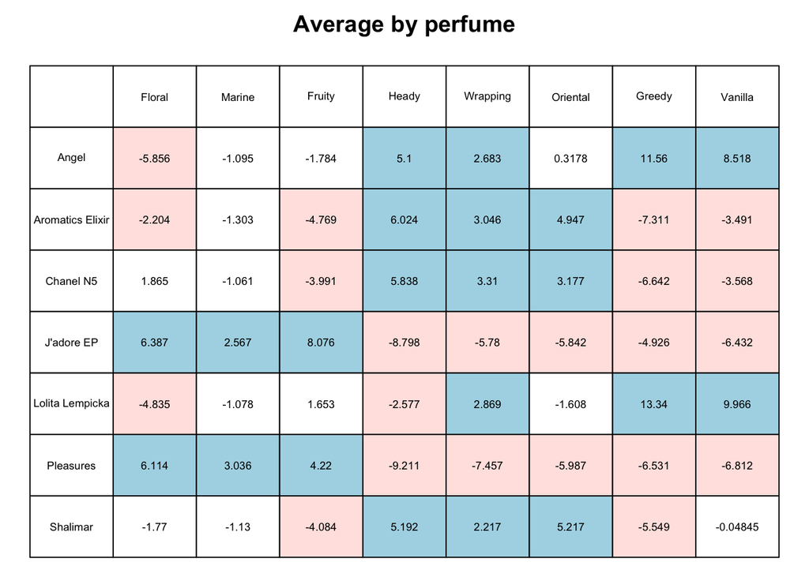

```r
experts_subset <- experts %>%
  select(c(Panelist,Product, Floral, Marine, Fruity, Heady, Wrapping, Oriental, Greedy, Vanilla)) %>%
  filter(Product == "Angel" | Product == "Pleasures" | Product == "J'adore EP" | Product == "Aromatics Elixir" | Product == "Shalimar" | Product == "Chanel N5" | Product == "Lolita Lempicka")
experts_subset <- droplevels(experts_subset)

resdecat <- decat(experts_subset, formul = "~Product+Panelist", firstvar = 3, graph = FALSE)


coltable(resdecat$tabT,
    level.lower = -1.96, level.upper = 1.96,
    main.title = "Average by perfume")
```

```r
magicsort(resdecat$tabT,method = "median")
```

```
##                     Greedy     Vanilla    Fruity    Floral    Marine   Oriental
## Pleasures        -6.530799 -6.81224649  4.220136  6.113721  3.035736 -5.9866495
## J'adore EP       -4.925694 -6.43213891  8.075978  6.386609  2.566850 -5.8419150
## Aromatics Elixir -7.311068 -3.49105116 -4.768882 -2.203629 -1.302694  4.9472940
## Shalimar         -5.548721 -0.04845122 -4.084194 -1.770361 -1.129797  5.2172619
## Lolita Lempicka  13.342750  9.96606593  1.652584 -4.834751 -1.077859 -1.6077853
## Chanel N5        -6.641930 -3.56830391 -3.991372  1.864805 -1.060540  3.1772851
## Angel            11.556438  8.51845621 -1.784409 -5.856225 -1.095175  0.3177612
## median           -5.548721 -3.49105116 -1.784409 -1.770361 -1.077859  0.3177612
##                   Wrapping     Heady     median
## Pleasures        -7.457108 -9.210901 -6.2587243
## J'adore EP       -5.780250 -8.797969 -5.3529720
## Aromatics Elixir  3.046386  6.023616 -1.7531612
## Shalimar          2.216559  5.192414 -0.5891239
## Lolita Lempicka   2.869497 -2.576723  0.2873627
## Chanel N5         3.309929  5.837724  0.4021326
## Angel             2.682795  5.099595  1.5002779
## median            2.682795  5.099595 -0.5891239
```

```r
magicsort(resdecat$tabT,method = "median")[-8,-9]
```

```
##                     Greedy     Vanilla    Fruity    Floral    Marine   Oriental
## Pleasures        -6.530799 -6.81224649  4.220136  6.113721  3.035736 -5.9866495
## J'adore EP       -4.925694 -6.43213891  8.075978  6.386609  2.566850 -5.8419150
## Aromatics Elixir -7.311068 -3.49105116 -4.768882 -2.203629 -1.302694  4.9472940
## Shalimar         -5.548721 -0.04845122 -4.084194 -1.770361 -1.129797  5.2172619
## Lolita Lempicka  13.342750  9.96606593  1.652584 -4.834751 -1.077859 -1.6077853
## Chanel N5        -6.641930 -3.56830391 -3.991372  1.864805 -1.060540  3.1772851
## Angel            11.556438  8.51845621 -1.784409 -5.856225 -1.095175  0.3177612
##                   Wrapping     Heady
## Pleasures        -7.457108 -9.210901
## J'adore EP       -5.780250 -8.797969
## Aromatics Elixir  3.046386  6.023616
## Shalimar          2.216559  5.192414
## Lolita Lempicka   2.869497 -2.576723
## Chanel N5         3.309929  5.837724
## Angel             2.682795  5.099595
```

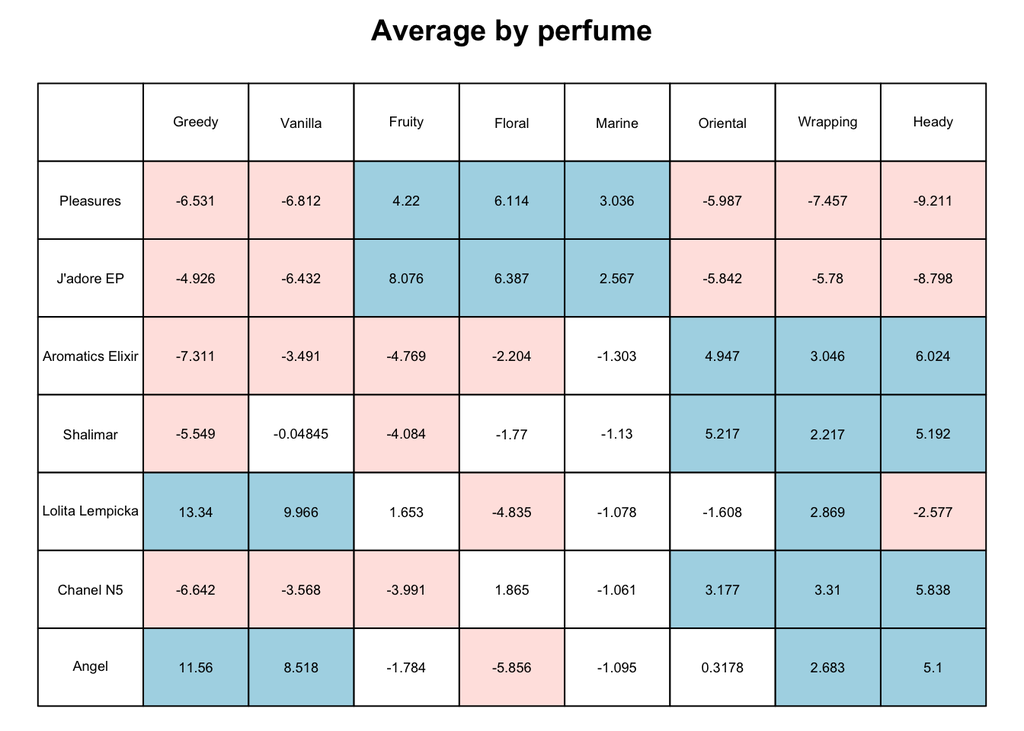

```r
coltable(magicsort(resdecat$tabT,method = "median")[-8,-9],
    level.lower = -1.96, level.upper = 1.96,
    main.title = "Average by perfume")
```

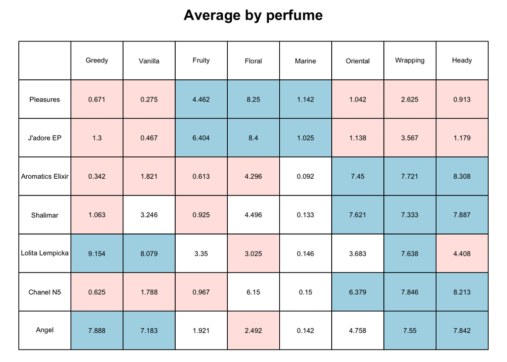

```r
coltable(magicsort(resdecat$tabT,method = "median")[-8,-9], magicsort(resdecat$tabT,method = "median")[-8,-9],
    level.lower = -1.96, level.upper = 1.96,
    main.title = "Average by perfume")

resaverage <- averagetable(experts_subset, formul = "~Product+Panelist", firstvar = 3)

resaverage.sort <- resaverage[rownames(magicsort(resdecat$tabT,method = "median"))[1:7], colnames(magicsort(resdecat$tabT,method = "median"))[1:8]]

coltable(round(resaverage.sort,3), magicsort(resdecat$tabT,method = "median")[-8,-9],
    level.lower = -1.96, level.upper = 1.96,
    main.title = "Average by perfume")
```

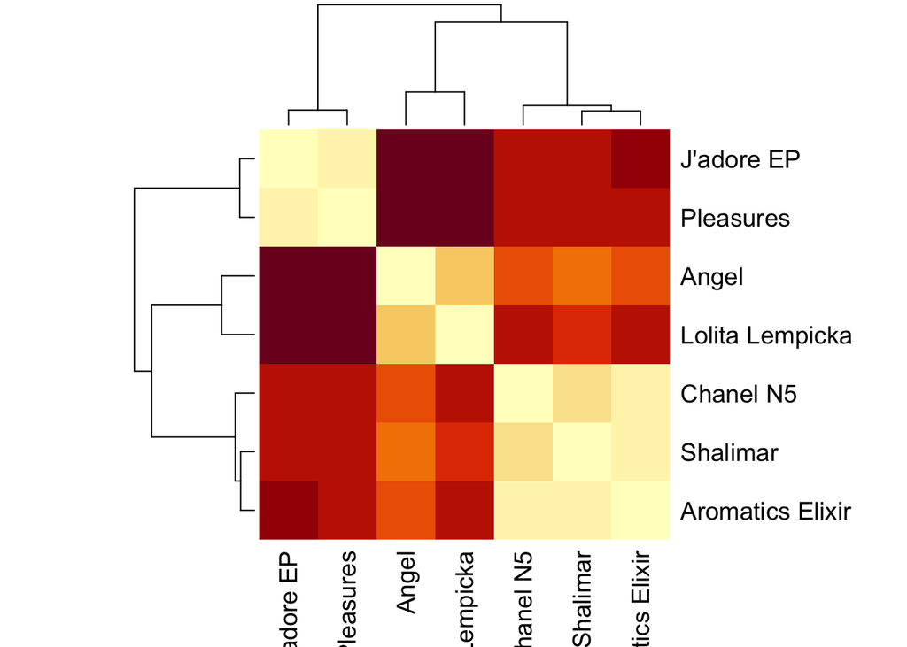

```r
dist.prod <- as.matrix(dist(resaverage))
heatmap(dist.prod, symm = TRUE)
```

> The *Stat* corner: playing with singular value decomposition

```r
res.svd <- svd(res_cr)

#Verification
res.svd$u%*%diag(res.svd$d)%*%t(res.svd$v)
```

```
##            [,1]       [,2]       [,3]       [,4]       [,5]        [,6]
## [1,] -1.2794682 -0.6089871 -0.3687676  0.7435489  0.5934280  0.06901798
## [2,] -0.4578436 -0.7249846 -1.0187684  0.8940244  0.6762252  1.11985746
## [3,]  0.3865512 -0.5896542 -0.8428128  0.8631232  0.7368086  0.70179903
## [4,]  1.4112101  1.4403028  1.8586239 -1.4047584 -1.3371604 -1.34457258
## [5,] -1.0365861 -0.5993206  0.3412652 -0.3635213  0.6358364 -0.35066713
## [6,]  1.3428995  1.7109637  0.8939730 -1.4907444 -1.7935548 -1.38198637
## [7,] -0.3667628 -0.6283200 -0.8635134  0.7583277  0.4884170  1.18655161
##            [,7]         [,8]
## [1,]  1.3883676  1.343032072
## [2,] -0.7577531 -0.495220121
## [3,] -0.6771699 -0.506646708
## [4,] -0.4851922 -0.959425220
## [5,]  1.7486220  1.650121599
## [6,] -0.6641344 -1.025128096
## [7,] -0.5527399 -0.006733525
```

```r
res_cr
```

```
##                        [,1]       [,2]       [,3]       [,4]       [,5]
## Angel            -1.2794682 -0.6089871 -0.3687676  0.7435489  0.5934280
## Aromatics Elixir -0.4578436 -0.7249846 -1.0187684  0.8940244  0.6762252
## Chanel N5         0.3865512 -0.5896542 -0.8428128  0.8631232  0.7368086
## J'adore EP        1.4112101  1.4403028  1.8586239 -1.4047584 -1.3371604
## Lolita Lempicka  -1.0365861 -0.5993206  0.3412652 -0.3635213  0.6358364
## Pleasures         1.3428995  1.7109637  0.8939730 -1.4907444 -1.7935548
## Shalimar         -0.3667628 -0.6283200 -0.8635134  0.7583277  0.4884170
##                         [,6]       [,7]         [,8]
## Angel             0.06901798  1.3883676  1.343032072
## Aromatics Elixir  1.11985746 -0.7577531 -0.495220121
## Chanel N5         0.70179903 -0.6771699 -0.506646708
## J'adore EP       -1.34457258 -0.4851922 -0.959425220
## Lolita Lempicka  -0.35066713  1.7486220  1.650121599
## Pleasures        -1.38198637 -0.6641344 -1.025128096
## Shalimar          1.18655161 -0.5527399 -0.006733525
```

```r
#Individuals coordinates
ind_coord <- res_cr%*%res.svd$v
#Variables coordinates
t(res_cr)%*%res.svd$u/sqrt(I)
```

```
##            [,1]        [,2]         [,3]        [,4]          [,5]         [,6]
## [1,] -0.9049436  0.38078823 -0.129075167 -0.11112061 -0.0598479805 -0.059053785
## [2,] -0.9911443 -0.04190992  0.117352206 -0.01808392  0.0390196335 -0.015979899
## [3,] -0.8673611 -0.43901462 -0.194919136  0.08210924  0.1004810196 -0.010911821
## [4,]  0.9232809  0.34100582  0.011758349 -0.10948779  0.1363909331 -0.023218976
## [5,]  0.9790362  0.03083657 -0.192779691 -0.03395342 -0.0344553667  0.032144774
## [6,]  0.8557568  0.49929639 -0.012798921  0.12497567  0.0004982329 -0.050995279
## [7,]  0.3908948 -0.91806609  0.001925755 -0.06563952  0.0029509156  0.005908836
## [8,]  0.6518873 -0.75346509  0.028415913  0.00885994 -0.0339101385 -0.072783534
##               [,7]
## [1,] -1.049062e-16
## [2,] -9.441559e-17
## [3,] -2.098124e-17
## [4,]  1.049062e-16
## [5,]  1.153968e-16
## [6,]  1.468687e-16
## [7,]  1.783406e-16
## [8,]  2.032558e-17
```

```r
#faire une représentation avec ind_coord et ggplot
```

> The *Algo* corner: the Nipals algorithm

```r
NIPALS <- function(X){
  X = as.matrix(X)
  N = nrow(X)
  M = ncol(X)

  D = diag(1/N, N)
  Xini = X
  qrX=qr(X)
  rang = qrX$rank
  vec=matrix(0,nrow=M,ncol=rang)
  t=X[,1]
  i=1

  p=t(X)%*%t%*%(1/(t(t)%*%t))
  p=p/as.numeric(sqrt(t(p)%*%p))
  print(rang)
  while (i<rang+1) {
    norm=1
    while(norm>0.000001){
      t=(X%*%p)%*%(1/(t(p)%*%p))
      p2=t(X)%*%t%*%(1/(t(t)%*%t))
      p2=p2/as.numeric(sqrt(t(p2)%*%p2))
      diff=p2-p
      norm=t(diff)%*%diff
      p=p2
      print(p)
      print(i)
    }
    vec[,i]=p
    X=X-(t%*%t(p))
    i=i+1
  }
  return(vec)
}

NIPALS(resaverage)
```

[output not shown]

[output cut: 486 more lines]

```
## Wrapping -0.07265446
## Oriental  0.36582443
## Greedy    0.48429280
## Vanilla  -0.52666482
## [1] 7
##                 [,1]
## Floral   -0.02964301
## Marine    0.56334152
## Fruity   -0.12325183
## Heady    -0.12472004
## Wrapping -0.07265452
## Oriental  0.36582439
## Greedy    0.48429274
## Vanilla  -0.52666488
## [1] 7
```

```
##            [,1]         [,2]        [,3]        [,4]          [,5]        [,6]
## [1,] 0.36805977 -0.688376120  0.25334236  0.20165126 -0.4969594342  0.11427437
## [2,] 0.02237359 -0.087837053  0.06967569  0.05456159 -0.0335164579  0.21372858
## [3,] 0.17238037 -0.319641420  0.47630879 -0.22482435  0.7493480972  0.11411687
## [4,] 0.48562708  0.093582782 -0.41433444  0.63950133  0.3283513978  0.22547052
## [5,] 0.53129479  0.025724717 -0.08269385 -0.20494170 -0.0240075342 -0.76816187
## [6,] 0.39666537 -0.002343827 -0.39795144 -0.59298957 -0.0003628924  0.33963482
## [7,] 0.26716919  0.473344738  0.53878871  0.23305495 -0.0292598566 -0.08486502
## [8,] 0.29578002  0.427518537  0.27734990 -0.22113235 -0.2848475451  0.40592523
##             [,7]
## [1,] -0.02964301
## [2,]  0.56334152
## [3,] -0.12325183
## [4,] -0.12472004
## [5,] -0.07265452
## [6,]  0.36582439
## [7,]  0.48429274
## [8,] -0.52666488
```

```r
svd(resaverage)$v
```

```
##             [,1]         [,2]        [,3]       [,4]         [,5]        [,6]
## [1,] -0.36797923 -0.687714741 -0.25654757 -0.2011865 -0.497041869  0.11584182
## [2,] -0.02236279 -0.087594567 -0.07008135 -0.0544929 -0.033137172  0.21385274
## [3,] -0.17233791 -0.318001734 -0.47779494  0.2241755  0.749970318  0.11178928
## [4,] -0.48564334  0.091661762  0.41470054 -0.6397530  0.327780834  0.22479034
## [5,] -0.53129879  0.025001913  0.08274482  0.2048238 -0.025355393 -0.76818346
## [6,] -0.39667069 -0.004133475  0.39788835  0.5930507  0.001371555  0.33936193
## [7,] -0.26721448  0.475134825 -0.53664530 -0.2330439 -0.029834486 -0.08467061
## [8,] -0.29582387  0.428314559 -0.27542220  0.2214600 -0.283585406  0.40666778
##             [,7]
## [1,] -0.02964301
## [2,]  0.56334152
## [3,] -0.12325183
## [4,] -0.12472004
## [5,] -0.07265452
## [6,]  0.36582439
## [7,]  0.48429274
## [8,] -0.52666488
```

# 4 From the inertia decomposition to Principal Components Analysis

Now, we know how is performed the PCA and how we get the coordinates of individuals or variables. To a better understanding of results, including supplementary information is very important and technically not complicated.

As PCA only uses continuous variables in the calculation of the distances between individuals, categorical variables can only be considered as supplementary. For continuous variables, determining whether they are illustrative or not is arbitrary, and depends on the point of view adopted. Often, continuous variables are considered as supplementary if they are from a different nature.

Supplementary individuals

We can use supplementary individuals to a better understanding of structures. For example, adding supplementary individuals that you already know characteristics is appropriate to compare new products. This requires knowledge and expertise that is external and specific to the study context.

# 5 From PCA to Multiple Factor Analysis

Here is an application of weighted PCA with MFA and the dataset wine

```r
library("FactoMineR")
library("factoextra")
data(wine)

# We keep actives variables
wine_quanti <- wine[, -c(1,2,30,31)]

group1 <- wine_quanti[, 1:5]
group2 <- wine_quanti[, 6:8]
group3 <- wine_quanti[, 9:18]
group4 <- wine_quanti[, 19:27]

# PCA on each group
res.pca1 <- PCA(group1)
```

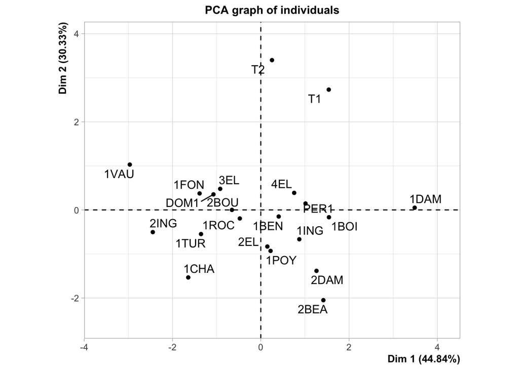

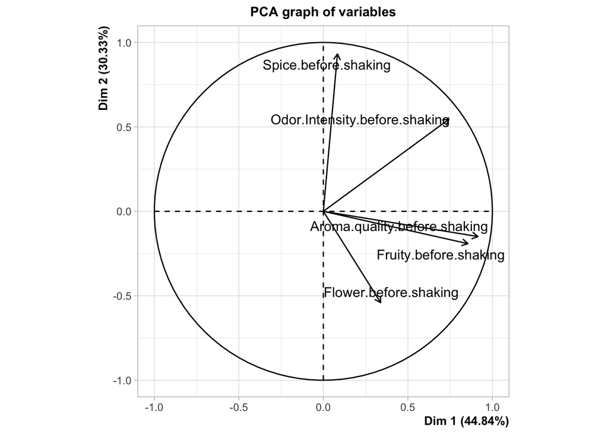

```r
res.pca2 <- PCA(group2)
```

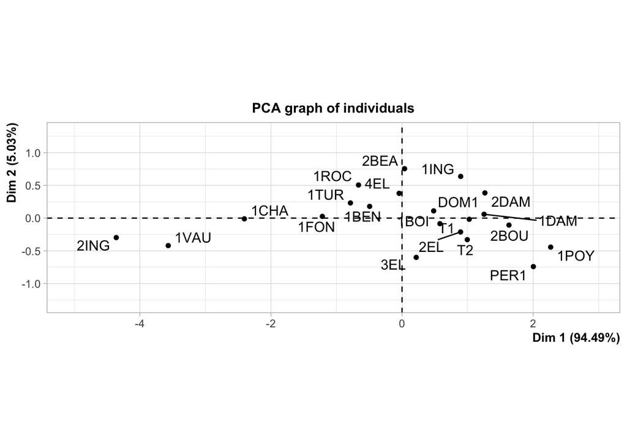

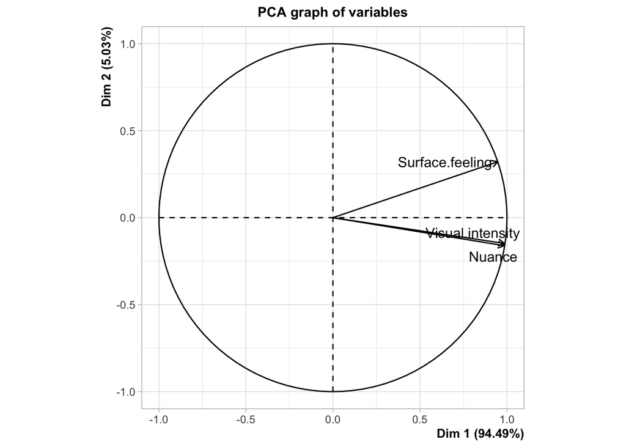

```r
res.pca3 <- PCA(group3)
```

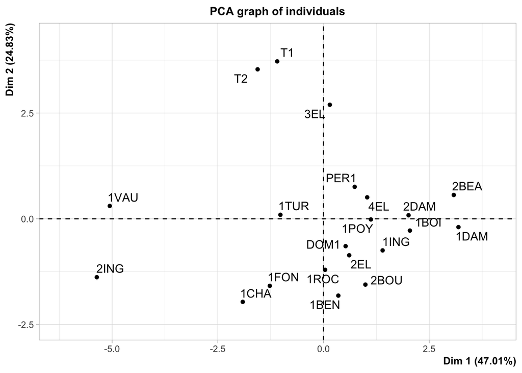

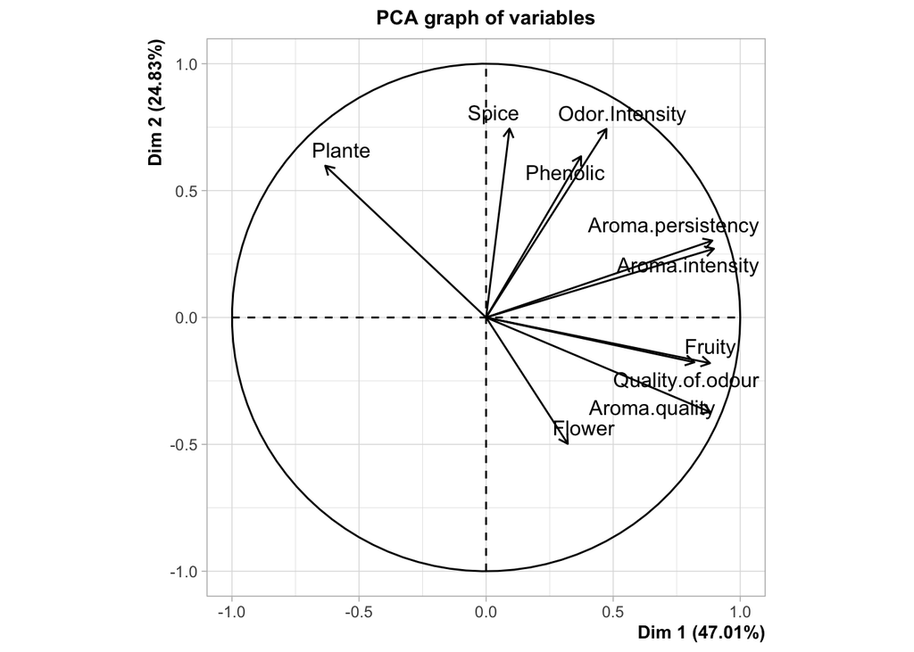

```r
res.pca4 <- PCA(group4)
```

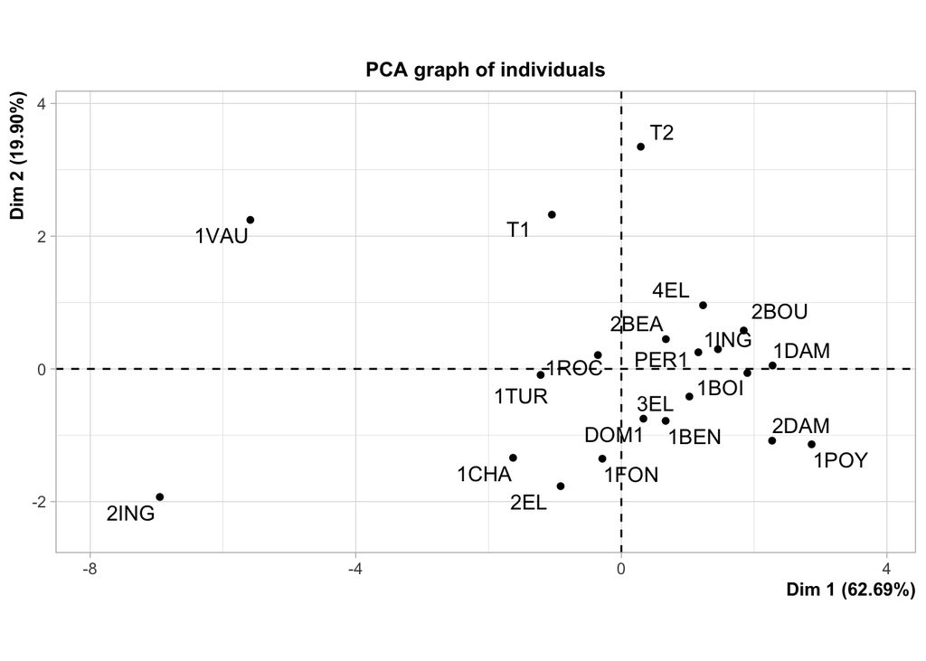

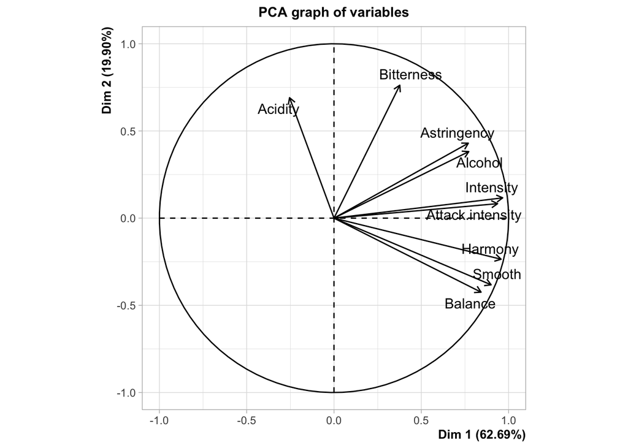

```r
# First eigen values of each PCA
egv1 <- res.pca1$eig[1]
egv2 <- res.pca2$eig[1]
egv3 <- res.pca3$eig[1]
egv4 <- res.pca4$eig[1]

# Vector of weight
w <- c(1/c(rep(egv1,5),rep(egv2,3),rep(egv3,10),rep(egv4,9) ))
res.pca.pon <- PCA(wine_quanti, col.w = w)
```

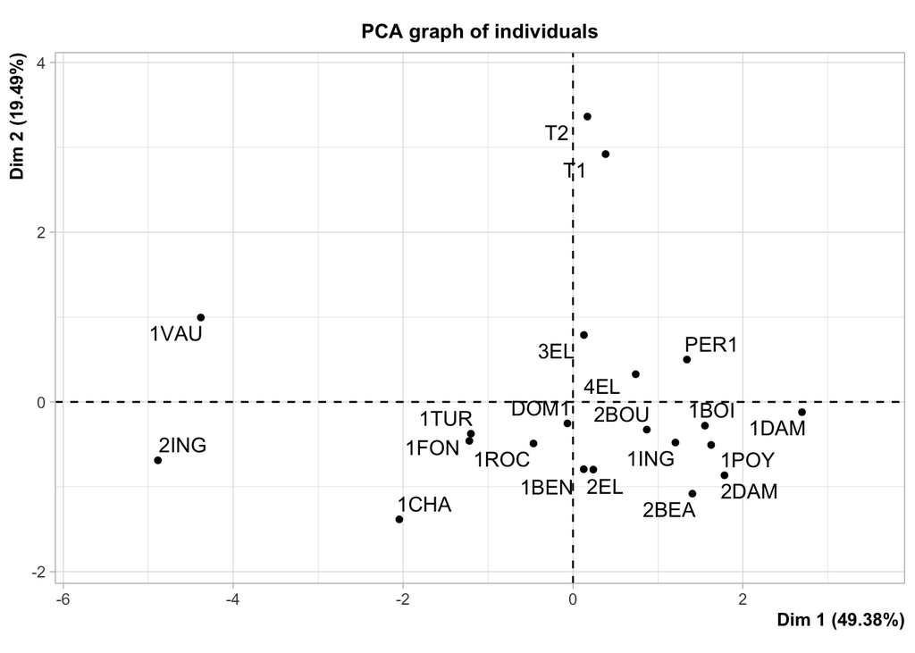

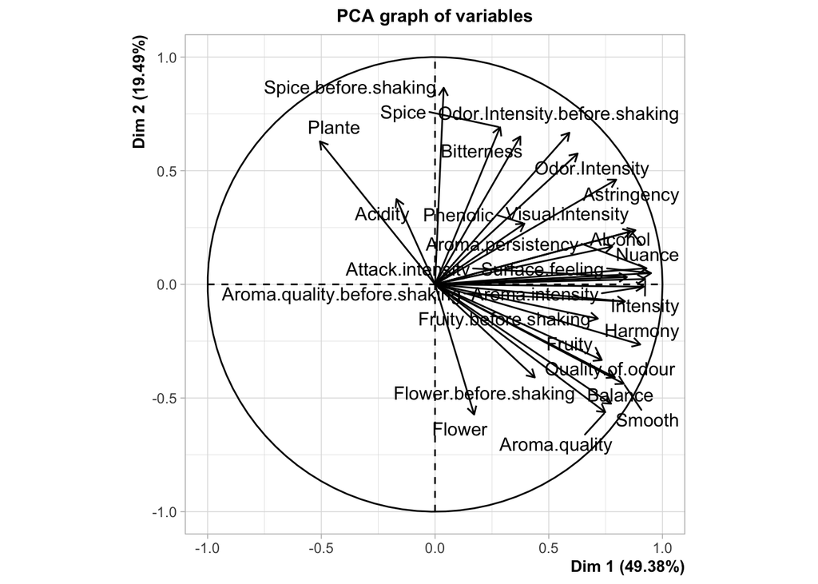

```r
coord_pca_pond <- res.pca.pon$ind$coord

res.pca.pon$eig
```

```
##          eigenvalue percentage of variance cumulative percentage of variance
## comp 1  3.461950436            49.37838239                          49.37838
## comp 2  1.366768270            19.49444613                          68.87283
## comp 3  0.615429078             8.77796864                          77.65080
## comp 4  0.372199671             5.30874662                          82.95954
## comp 5  0.270382485             3.85651094                          86.81605
## comp 6  0.202403306             2.88691245                          89.70297
## comp 7  0.175713405             2.50622990                          92.20920
## comp 8  0.125898681             1.79571410                          94.00491
## comp 9  0.105275528             1.50156260                          95.50647
## comp 10 0.078791202             1.12381220                          96.63029
## comp 11 0.073892411             1.05393990                          97.68423
## comp 12 0.060338440             0.86061733                          98.54484
## comp 13 0.028705009             0.40942438                          98.95427
## comp 14 0.021962548             0.31325552                          99.26752
## comp 15 0.019163991             0.27333923                          99.54086
## comp 16 0.010940292             0.15604323                          99.69691
## comp 17 0.009156013             0.13059375                          99.82750
## comp 18 0.006370966             0.09087016                          99.91837
## comp 19 0.003303413             0.04711714                          99.96549
## comp 20 0.002419756             0.03451339                         100.00000
```

```r
svd.triplet(scale(wine_quanti))
```

```
## $vs
##  [1] 3.61295326 2.20226543 1.38076901 1.12625464 1.01561112 0.87967909
##  [7] 0.84236691 0.70664232 0.62013776 0.57152922 0.54104222 0.44944501
## [13] 0.32917308 0.30363628 0.28135146 0.21358851 0.19973900 0.16698881
## [19] 0.11302799 0.09926405
##
## $U
##               [,1]       [,2]       [,3]        [,4]       [,5]        [,6]
##  [1,]  0.036255139 -0.7647504  1.0566915  1.31680667 -1.0922361 -0.76069998
##  [2,] -0.999859978 -1.1849182  1.9766596  0.93964272  0.2632444 -1.45854496
##  [3,] -0.530459656 -0.6644336  0.3297412 -2.19304355  0.1709513 -0.96532506
##  [4,] -2.380742580  0.8537871 -0.2401820  0.35022433  2.2625076  1.36991052
##  [5,]  1.323022707 -0.1459355 -0.8401188  0.62982139  1.2144731 -1.49706822
##  [6,]  0.566883246 -0.3244310  0.4248359 -1.64735226  0.2383087  1.21862241
##  [7,]  0.843547631 -0.2433954 -0.6147270 -0.56641861  1.4648831 -0.05431734
```

[output cut: 194 more lines]

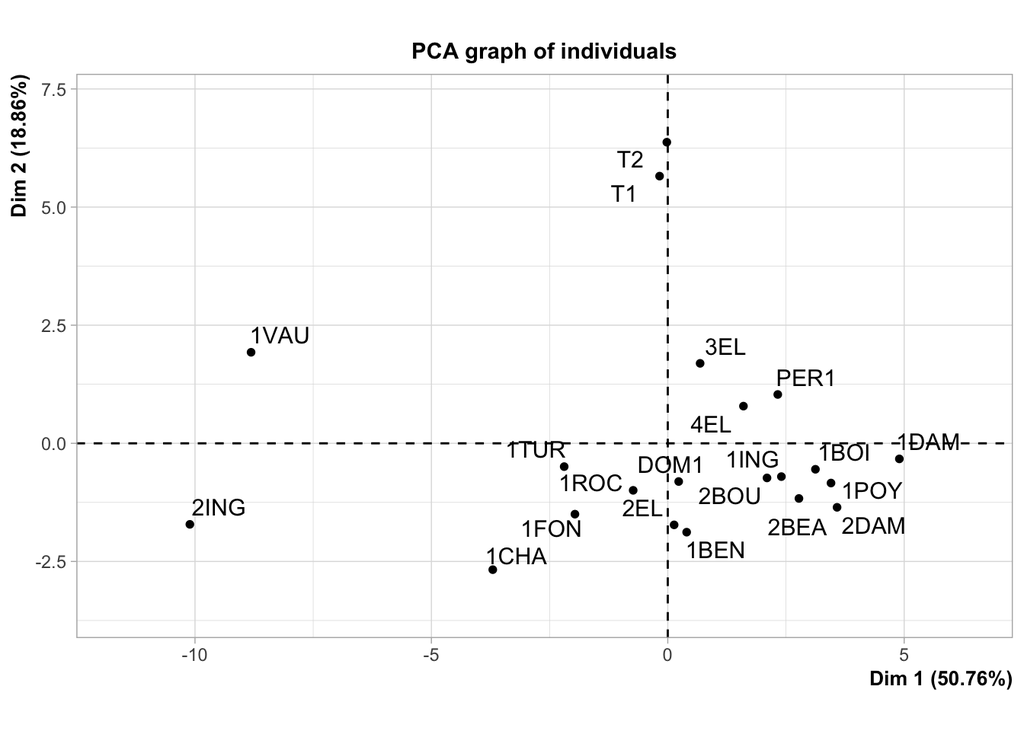

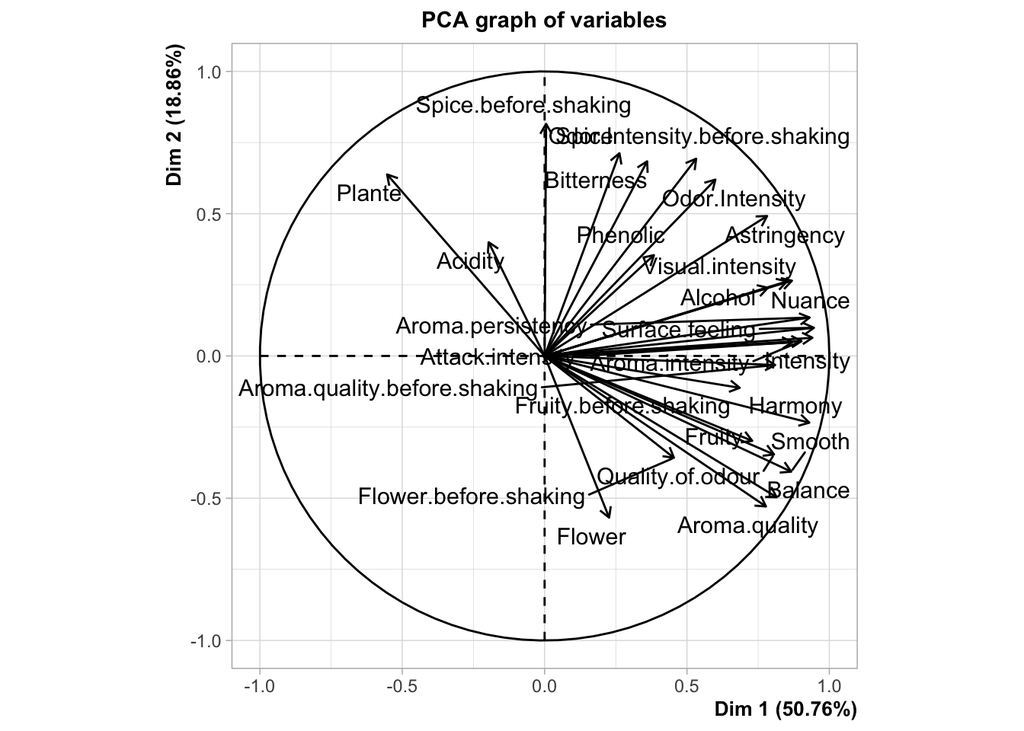

```
## $vs
##  [1] 3.7021754 2.2566505 1.4148672 1.1540676 1.0406917 0.9014028 0.8631692
##  [8] 0.7240929 0.6354521 0.5856432 0.5544033 0.4605441 0.3373020 0.3111346
## [15] 0.2882995 0.2188631 0.2046716 0.1711126 0.1158192 0.1017154
##
## $U
##               [,1]       [,2]       [,3]        [,4]       [,5]
##  [1,]  0.036255139 -0.7647504  1.0566915  1.31680667 -1.0922361
##  [2,] -0.999859978 -1.1849182  1.9766596  0.93964272  0.2632444
##  [3,] -0.530459656 -0.6644336  0.3297412 -2.19304355  0.1709513
##  [4,] -2.380742580  0.8537871 -0.2401820  0.35022433  2.2625076
##  [5,]  1.323022707 -0.1459355 -0.8401188  0.62982139  1.2144731
##  [6,]  0.566883246 -0.3244310  0.4248359 -1.64735226  0.2383087
##  [7,]  0.843547631 -0.2433954 -0.6147270 -0.56641861  1.4648831
##  [8,]  0.184774999  0.7499969  2.4551505  0.79606560 -0.5128170
```

[output cut: 43 more lines]

```r
PCA(wine_quanti)$svd
```

> Ajout des blocs déjà faits

# 6 I. Variance and inertia

## 6.1 Center of gravity

We have seen how to define the variance of a quantitative variable. We can also see the variance more geometrically on an axis. Let’s use the variable `Vanilla` from the same data set used in the lesson 1.

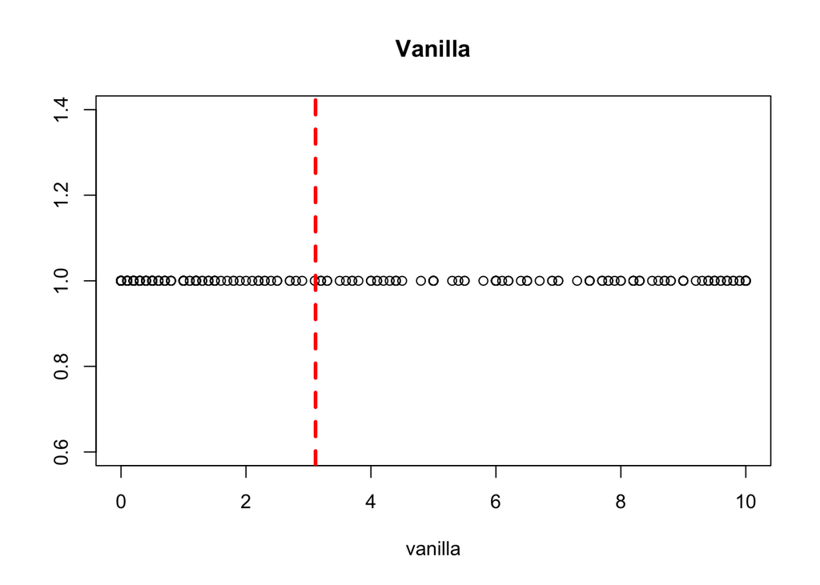

```r
vanilla <- experts$Vanilla

plot(x=vanilla, y=rep(1, length(vanilla)), main="Vanilla", ylab="")
abline(v = mean(vanilla), col="red", lwd=3, lty=2)
```

We can see the observations of the variable as points in a one-dimensional space with the mean center of gravity. Let us generalize this vision with two variables:

```r
df <- data.frame(experts$Vanilla, experts$Citrus)
colnames(df) <- c("Vanilla", "Citrus")
```

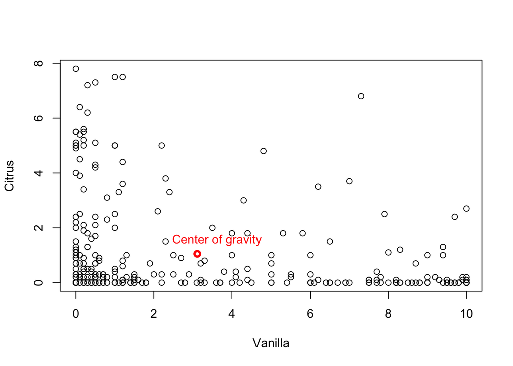

```r
plot(df)
points(x=mean(df$Vanilla),y=mean(df$Citrus), type="p", col="red",lwd=3, lty=2)
text(mean(df$Vanilla)+0.5, mean(df$Citrus)+0.5, "Center of gravity", col="red")
```

The center of gravity is the point $(\bar{Vanilla}, \bar{Citrus})$. If we take more than 2 variables, the center of gravity will be the matrix of means of variables. Let’s take all the quantitative variables of the data set :

```r
df <- data.frame(experts[,5:16])
```

Put the coordinates of the center of gravity for this dataframe :

```r
colMeans(df)
```

```
##     Spicy     Heady    Fruity     Green   Vanilla    Floral     Woody    Citrus
## 2.2493056 3.9628472 3.4868056 0.8458333 3.1131944 6.1187500 1.2524306 1.0489583
##    Marine    Greedy  Oriental  Wrapping
## 0.4673611 2.9236111 3.6993056 5.7368056
```

## 6.2 Inertia

Let’s do it with all quantitative variables for the 10th first individuals. For this, you must to calculate the matrix of the center of gravity $n \times p$ and the matrix of distances using the `apply()` function of R:

```r
matG <- matrix(colMeans(df[1:10,]), nrow(df[1:10,]), ncol(df) , byrow=TRUE)
apply((df[1:10,] - matG)^2, 1, sum)
```

```
##        1        2        3        4        5        6        7        8
##  54.8174  70.1114 108.5314  43.2574  84.1894 124.8754  61.6274  82.2814
##        9       10
## 100.5914  62.8834
```

Hide : the result is the vector of 10 distances of individuals between each coordinates of the enter of gravity.

```r
distG <- apply((df[1:10,] - matG)^2, 1, sum)
sum(distG)/(nrow(df[1:10,])-1)
```

```
## [1] 88.12956
```

## 6.3 Sum of the variance

Build the vector of the variances of the 12 variables of df:

```r
variances <- c()
for (j in 1:12){
  variances <- cbind(variances, var(df[1:10,j]))
}
variances
```

```
##          [,1]     [,2]     [,3]      [,4]     [,5]     [,6]     [,7]     [,8]
## [1,] 6.884889 19.13656 13.11611 0.6721111 3.039556 4.649889 1.595111 5.362667
##          [,9]    [,10]    [,11]    [,12]
## [1,] 4.068889 13.74889 11.98322 3.871667
```

Now, calculate the sum of this vector :

```r
sum(variances)
```

```
## [1] 88.12956
```

Compare the result found here and the one found in the previous section. Then understand this:

$\frac{1}{n}\sum_{i=1}^{n} d^{2}(x_{i}, g))\Leftrightarrow \frac{1}{n}\sum_{i=1}^{n} \sum_{j=1}^{p}(x_{ij}-x_{.j})^{2})) \Leftrightarrow \sum_{j=1}^{p} \frac{1}{n}\sum_{i=1}^{n}(x_{ij}-x_{.j})^{2}))\Leftrightarrow \sum_{j=1}^{p} Var(X_{j}))$

# 7 II .Bivariate analysis: two quantitative variables

For this part, we focus on the relation between the variable `Fruity` and `Floral`. Exist it a relation between this two attributes ?

```r
df <- data.frame(experts$Fruity, experts$Floral)
colnames(df) <- c("Fruity", "Floral")
```

To begin, plot the observations of the `Floral` attribute in function of the `Fruity` attribuet :

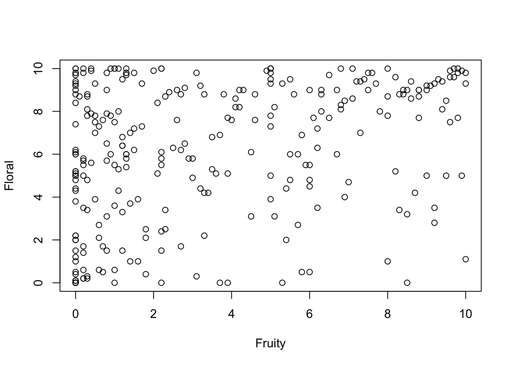

```r
plot(df)
```

What’s the information can we obtain with this plot ? - the comportement of a variable with an other, for example if `Fruity` increase, `Floral` increased too. It’s a linear relation. - wrong answer - wrong answer

## 7.1 Covariance

In the first part of this lesson we calculate the variance for one variable. Here, we use the covariance matrix. It’s an indicator of the linear direction between 2 variables.

$Cov(X,Y)=\frac{1}{N-1}\sum_{n}^{1}(x_{i}-\bar{x})(y_{i}-\bar{y})$ Try to calculate manually the covariance between this two variable :

```r
N <- length(df$Floral)
1/(N-1)*sum((df$Fruity-mean(df$Fruity))*(df$Floral-mean(df$Floral)))
```

```
## [1] 3.377809
```

Verify your answer with the `cov()` function of R :

```r
cov(df$Fruity,df$Floral)
```

```
## [1] 3.377809
```

## 7.2 Correlation

The correlation between two variables indicate any type of association refers to the degree to which a pair of variables are linearly related. It’s a measure of dependence, the most familiar measure is the Pearson correlation coefficient : $\rho_{XY} = corr(X,Y) = \frac{cov(X,Y)}{\sigma_{X}\sigma_{Y}}$

Try to calculate the correlation coefficient between `Fruity` and `Floral` :

```r
cov <- 1/(N-1)*sum((df$Fruity-mean(df$Fruity))*(df$Floral-mean(df$Floral)))
cov / (sqrt(var(df$Fruity))*sqrt(var(df$Floral)))
```

```
## [1] 0.3188781
```

Verify your answer with the `cor()` function of R :

```r
cor(df$Fruity, df$Floral)
```

```
## [1] 0.3188781
```

# 8 III. Test-F

## 8.1 Context and formalisation

The test-F is a statistic test that determines the equality of variances of two populations, this makes it possible to compare two population variances. Both populations are presumed to be Gaussian.

## 8.2 Construction of the test statistics

Under the hypothesis of equality of variances we deduce that the random variable :

$\frac{\frac{n_{1}S^{2}_{1}}{n_{1}-1}}{\frac{n_{2}S^{2}_{2}}{n_{2}-1}} \sim \mathcal{F}(n_{1}-1, n_{2}-1)$

## 8.3 Decision

In this case, the comparison test being bilateral, H0 is rejected at the risk threshold $\alpha$ in the cases:

- $f_{obs}\le f_{\frac{\alpha}{2}}(v_{1},v_{2})$;
- $f_{obs}\ge f_{1-\frac{\alpha}{2}}(v_{1},v_{2})$.

Hence the decision rule, H0 is rejected if : $f_{obs} \notin [f_{\frac{\alpha}{2}}(n_{1}-1,n_{2}-1),f_{1-\frac{\alpha}{2}}(n_{1}-1,n_{2}-1)]$

## 8.4 Practice

### 8.4.1 Manually

In Argentina, an experiment was conducted in 2009 to solve problems related to the intensification of agriculture and especially to a new method cattle feeding. The traditional A.Angus breed is not adapted to this system breeding, a cross: A.Angus x Charolaise was created. The objective is to obtain animals better adapted to these new practices while maintaining a homogeneity comparable to the traditional breed. The character studied is the GMQ (Average Daily Gain) expressed in kg.

The results observed on two batches (here in the sense of “samples”) are as follows:

- for lot 1: pure breed, sample size 16, variance 0.26.
- for lot 2: cross-breed, sample size: 21, variance: 0.37.

Can we consider that the GMQ of cross A . Angus x Charolaise gives results as homogeneous as that of the pure race? (we will take a risk threshold of 0.05).

Calculate $f_{obs}$ and the quantiles of the fisher law :

```r
f <- (16*0.26/15)/(21*0.37/20)
v1 <- qf(0.025,df1=15,df2=20)
v2 <- qf(0.975,df1=15,df2=20)
```

What’s the conclusion ? - $H0$ rejected - $H0$ not rejected

### 8.4.2 Using R

```r
var.test(experts$Spicy, experts$Heady)
```

```
##
##  F test to compare two variances
##
## data:  experts$Spicy and experts$Heady
## F = 0.65448, num df = 287, denom df = 287, p-value = 0.0003511
## alternative hypothesis: true ratio of variances is not equal to 1
## 95 percent confidence interval:
##  0.5190462 0.8252493
## sample estimates:
## ratio of variances
##          0.6544789
```

Calculate manually the f-statistic :

```r
(288*var(experts$Spicy)/287)/(288*var(experts$Heady)/287)
```

```
## [1] 0.6544789
```

# 9 VI. Khi²

## 9.1 Cross tabulation

The easiest way to obtain a cross tabulation is to use the table function by giving it as parameters the two variables to cross.

```r
library(dplyr)
library(questionr)
data_fruity <- experts %>% filter(Fruity>6)
data_table <- table(data_fruity$Product)
tab <- table(data_fruity$Product, data_fruity$Panelist)
cprop(tab)
```

```
##
##                     CM    CR    GV    MLD   NMA   PR    RL    SD    SM    SO
##   Angel               0.0  16.7   0.0   0.0   0.0   0.0   0.0   0.0   0.0   0.0
##   Cinéma             20.0   0.0  14.3  20.0   0.0   0.0  33.3   0.0   0.0  10.0
##   Coco Mademoiselle   0.0   0.0  28.6  20.0  16.7   0.0   0.0   0.0   0.0  20.0
##   J'adore EP         20.0  16.7  14.3  20.0  16.7  50.0   0.0  50.0  33.3  20.0
##   J'adore ET          0.0  16.7  14.3  20.0   0.0  50.0   0.0  50.0  33.3  20.0
##   L'instant           0.0  16.7  14.3   0.0  33.3   0.0   0.0   0.0   0.0   0.0
##   Lolita Lempicka    40.0  16.7  14.3   0.0   0.0   0.0   0.0   0.0   0.0  10.0
##   Pleasures          20.0  16.7   0.0  20.0  16.7   0.0  33.3   0.0   0.0  10.0
##   Pure Poison         0.0   0.0   0.0   0.0  16.7   0.0  33.3   0.0  33.3  10.0
##   Total             100.0 100.0 100.0 100.0 100.0 100.0 100.0 100.0 100.0 100.0
##
##                     ST    Ensemble
##   Angel               0.0   2.7
##   Cinéma             15.4  11.0
##   Coco Mademoiselle  15.4  12.3
##   J'adore EP         15.4  19.2
##   J'adore ET         15.4  16.4
##   L'instant          15.4   9.6
##   Lolita Lempicka     0.0   8.2
##   Pleasures           7.7  12.3
##   Pure Poison        15.4   8.2
##   Total             100.0 100.0
```

## 9.2 Study the cross table of the 2 variables

The idea is if two variables I and J are independent, then we expect the number of individuals nij who satisfy I and J to be equal to eff_theo = ni.*nj./n On the contrary, if nij is significantly different from fi*nj , the more reason here is to think that I and J are not independent.

Studying a correlation between two categorical variables leads to comparing the nij with the eff_theo.

```r
data(tea)
summary(tea)
```

```
##          breakfast           tea.time          evening          lunch
##  breakfast    :144   Not.tea time:131   evening    :103   lunch    : 44
##  Not.breakfast:156   tea time    :169   Not.evening:197   Not.lunch:256
##
##
##
##
##
##         dinner           always          home           work
##  dinner    : 21   always    :103   home    :291   Not.work:213
##  Not.dinner:279   Not.always:197   Not.home:  9   work    : 87
##
##
##
##
##
##         tearoom           friends          resto          pub
##  Not.tearoom:242   friends    :196   Not.resto:221   Not.pub:237
##  tearoom    : 58   Not.friends:104   resto    : 79   pub    : 63
##
##
##
##
##
##         Tea         How           sugar                     how
##  black    : 74   alone:195   No.sugar:155   tea bag           :170
##  Earl Grey:193   lemon: 33   sugar   :145   tea bag+unpackaged: 94
##  green    : 33   milk : 63                  unpackaged        : 36
##                  other:  9
##
##
##
##                   where                 price          age        sex
##  chain store         :192   p_branded      : 95   Min.   :15.00   F:178
##  chain store+tea shop: 78   p_cheap        :  7   1st Qu.:23.00   M:122
##  tea shop            : 30   p_private label: 21   Median :32.00
##                             p_unknown      : 12   Mean   :37.05
##                             p_upscale      : 53   3rd Qu.:48.00
##                             p_variable     :112   Max.   :90.00
##
```

[output cut: 25 more lines]

```
##  feminine    :129   Not.sophisticated: 85   No.slimming:255   exciting   :116
##  Not.feminine:171   sophisticated    :215   slimming   : 45   No.exciting:184
##
##
##
##
##
##         relaxing              effect.on.health
##  No.relaxing:113   effect on health   : 66
##  relaxing   :187   No.effect on health:234
##
##
##
##
##
```

```r
tab <- table(tea$breakfast,tea$tea.time)
tab
```

```
##
##                 Not.tea time tea time
##   breakfast               55       89
##   Not.breakfast           76       80
```

construct the theorical table :

```r
theo11 <- (sum(tab[1,])*sum(tab[,1]))/sum(tab)
theo12 <- (sum(tab[1,])*sum(tab[,2]))/sum(tab)
theo21 <- (sum(tab[2,])*sum(tab[,1]))/sum(tab)
theo22 <- (sum(tab[2,])*sum(tab[,2]))/sum(tab)
theo <- cbind(c(theo11,theo21),c(theo12,theo22))
colnames(theo)<-colnames(tab)
row.names(theo)<- row.names(tab)
theo
```

```
##               Not.tea time tea time
## breakfast            62.88    81.12
## Not.breakfast        68.12    87.88
```

```r
tab
```

```
##
##                 Not.tea time tea time
##   breakfast               55       89
##   Not.breakfast           76       80
```

We have to compare now the 2 tables.

First, we substract all theorical values to experimental values:

```r
newtab <- tab-theo
```

Then we take the square value:

```r
newtab <- newtab^2
```

Finally, we divide by the theorical effectifs :

```r
newtab <- newtab/theo
newtab
```

```
##
##                 Not.tea time  tea time
##   breakfast        0.9875064 0.7654635
##   Not.breakfast    0.9115443 0.7065817
```

This table is called the table of deviations from independence

The sum of the table give the Chi2 statistic:

```r
chi2 <- sum(newtab)
chi2
```

```
## [1] 3.371096
```

# 10 VII. condes()

## 10.1 What’s the concept?

The `condes()` function from FactoMineR is using when you want to comparate a quantitative variable with other variable. The function identifies the type of others by itself and returns

- the description of the `num.var` by the quantitative variables in the `quanti` argument or/and the categorical variables which characterized the continuous variable renseigned in `num.var`, in the `quali` argument;
- and when others variables are qualitatives, the `category` returns a description of the continuous variable `num.var` by each category of all the categorical variables.

## 10.2 Compare with a quantitative variable

In our case, we use the function on the data frame composed of `Floral` and `Fruity` variables :

```r
res.condes <- condes(donnee = data.frame(experts$Fruity, experts$Floral), num.var = 1)
```

Reminder the description of the function, in our case, what’s return ? - only `quanti` - `quanti` and `quali` - `quanti`, `quali` and `category`

Let’s get a look on argument(s) :

```r
res.condes$quanti
```

```
##                correlation      p.value
## experts.Floral   0.3188781 3.145829e-08
```

Here, it’s tested if the correlation coefficient is significantly different from zero. The null hypothesis is $H0 : \rho = 0$, there is not significant linear relationship between the two variables and the alternate hypothesis is $H1 : \rho \ne 0$. Get a look on the p-value, what can you conclude ? - there is a significant linear relationship between `Fruity` and `Floral`; - there is not a significant linear relationship between `Fruity` and `Floral`. *Hind* : When the p-value < 0.05, H0 is rejected. It’s the case here so there is a significant correlation between them.

## 10.3 Compare with a qualitative variable

```r
res.condes <- condes(donnee = data.frame(experts$Fruity, experts$Product), num.var = 1)
res.condes$quali
```

```
##                        R2      p.value
## experts.Product 0.3364909 1.834564e-19
```

Here a one-factor variance analysis test is performed.

The first argument is the $R^{2}$ statistic. It represents the percentage of variation in a response variable (here `Fruity`) explained by its relationship with one or more predictor (here `Product`).

The second argument is the p-value from an ANOVA.

With this result, what can you conclude ? - the products have been differentiated regarding the sensory attribute `Fruity`; - the products haven’t been differentiated regarding the sensory attribute `Fruity`

## 10.4 Use all the data

Let’s apply on the entire dataset. We choose to describe the first quantitative variable `Spicy` :

```r
res.condes <- condes(donnee = experts, num.var = 5)
```

Print results for the quantitative variables first, then for the qualitative variables:

```r
res.condes$quanti
```

```
##          correlation      p.value
## Heady      0.6600235 2.115480e-37
## Oriental   0.5746949 1.033259e-26
## Wrapping   0.4054195 8.062952e-13
## Woody      0.3900676 6.662342e-12
## Vanilla    0.1559591 8.014781e-03
## Citrus    -0.1345029 2.242761e-02
## Green     -0.1411124 1.655947e-02
## Fruity    -0.3514545 8.501233e-10
## Floral    -0.3540310 6.273945e-10
```

```r
res.condes$quali
```

```
##                 R2      p.value
## Product  0.4539609 1.444200e-30
## Panelist 0.1231426 1.219991e-04
```

You can see that only significant variables are displayed in both cases.

Next, an other result of the `condes` function is :

```r
res.condes$category
```

```
##                            Estimate      p.value
## Product=Aromatics Elixir   4.054861 7.857853e-12
## Product=Shalimar           3.913194 4.623115e-11
## Panelist=NMA               2.775694 4.642950e-06
## Product=Angel              1.650694 7.111351e-03
## Product=Chanel N5          1.484028 1.565503e-02
## Rank=1                    -1.228472 4.577800e-02
## Product=Coco Mademoiselle -1.336806 2.963114e-02
## Panelist=SM               -1.399306 2.275146e-02
## Product=L'instant         -1.511806 1.379422e-02
## Panelist=CR               -1.595139 9.325197e-03
## Product=Pleasures         -1.757639 4.125228e-03
## Product=J'adore ET        -1.907639 1.825387e-03
## Product=J'adore EP        -1.986806 1.158113e-03
```

In practice, this result is more important than the other two because we’re interested by the differences within the product groups themselves. The p-value returned is that of the t-test. Here, for each product $i$ the t-test is performed with $H0: \mu_{i} = \mu$ with $\mu_{i}$ the mean estimator of `Spicy` in the group $i$ and $\mu$ the mean estimator for the global population.

# 11 VIII. catdes()

## 11.1 What’s the concept?

The `catdes()` function from FactoMineR is using when you want to comparate a qualitative variable with other variable. The function identifies the type of others by itself and returns

- the description of the `num.var` by the quantitative variables in the `quanti` argument and the $\eta^{2}$-score in for each quantitative variable in the `quanti.var` argument;
- the categorical variables which characterized the continuous variable renseigned in `num.var`, in the `test.chi2` argument; and the `category` returns a description of the continuous variable `num.var` by each category of all the categorical variables.

## 11.2 Compare with a quantitative variable

Let’s start to compare the variable `Product` with the quantitative variable `Green`

```r
res.catdes <- catdes(donnee = data.frame(experts$Product, experts$Green), num.var = 1)
```

Reminder the description of the function, in our case, what’s return ? - only `quanti`; - `quanti` and `quanti.var`; - only `test.chi2`; - `test.chi2` and `category`; - `quanti`, `quanti.var`,`test.chi2` and `category`.

Let’s get a look on argument(s) :

```r
res.catdes$quanti.var
```

```
##                    Eta2      P-value
## experts.Green 0.2555684 4.331956e-13
```

```r
res.catdes$quanti
```

```
## $Angel
##                  v.test Mean in category Overall mean sd in category Overall sd
## experts.Green -2.235428           0.1125    0.8458333      0.1786815   1.675658
##                  p.value
## experts.Green 0.02538928
##
## $`Aromatics Elixir`
## NULL
##
## $`Chanel N5`
## NULL
##
## $Cinéma
## NULL
##
## $`Coco Mademoiselle`
## NULL
##
## $`J'adore EP`
##                 v.test Mean in category Overall mean sd in category Overall sd
## experts.Green 2.184623           1.5625    0.8458333       2.076418   1.675658
##                  p.value
## experts.Green 0.02891653
##
## $`J'adore ET`
## NULL
##
## $`L'instant`
## NULL
##
## $`Lolita Lempicka`
## NULL
##
## $Pleasures
##                 v.test Mean in category Overall mean sd in category Overall sd
## experts.Green 7.328647             3.25    0.8458333       2.983426   1.675658
##                    p.value
## experts.Green 2.324885e-13
##
## $`Pure Poison`
## NULL
##
## $Shalimar
## NULL
```

In `quanti.var`, $\eta^{2}$ ranges from 0 to 1 and where values closer to 1 indicate a higher proportion of variance can be explained by a given variable in the ANOVA model performed. The p-value is that of this one-factor ANOVA.

In `quanti`, the v-test performed is very close to the notion of z-score. In its basic form, the V-test is the quantile of a standardized normal distribution (with mean equal to 0 and standard deviation equal to 1) corresponding to a given probability. It is used to transform p-values into scores that are more easily interpretable. The result is displayed as “NULL” for certain modality. This is because the probability used is by default 5%. To display the results for all modalities, change the `proba` argument. Do it:

```r
catdes(donnee = data.frame(experts$Product, experts$Green), num.var = 1, proba=1)
```

```
##
## Link between the cluster variable and the quantitative variables
## ================================================================
##                    Eta2      P-value
## experts.Green 0.2555684 4.331956e-13
##
## Description of each cluster by quantitative variables
## =====================================================
## $Angel
##                  v.test Mean in category Overall mean sd in category Overall sd
## experts.Green -2.235428           0.1125    0.8458333      0.1786815   1.675658
##                  p.value
## experts.Green 0.02538928
##
## $`Aromatics Elixir`
##                  v.test Mean in category Overall mean sd in category Overall sd
## experts.Green -1.003402        0.5166667    0.8458333      0.9361564   1.675658
##                 p.value
## experts.Green 0.3156668
##
## $`Chanel N5`
##                  v.test Mean in category Overall mean sd in category Overall sd
## experts.Green -1.244727           0.4375    0.8458333      0.6136044   1.675658
##                 p.value
## experts.Green 0.2132322
##
## $Cinéma
##                  v.test Mean in category Overall mean sd in category Overall sd
## experts.Green -1.930597           0.2125    0.8458333      0.2962438   1.675658
##                  p.value
## experts.Green 0.05353295
##
## $`Coco Mademoiselle`
##                   v.test Mean in category Overall mean sd in category
## experts.Green -0.2032207        0.7791667    0.8458333       1.367473
##               Overall sd   p.value
## experts.Green   1.675658 0.8389625
##
## $`J'adore EP`
##                 v.test Mean in category Overall mean sd in category Overall sd
```

[output cut: 24 more lines]

```
## experts.Green 7.328647             3.25    0.8458333       2.983426   1.675658
##                    p.value
## experts.Green 2.324885e-13
##
## $`Pure Poison`
##                   v.test Mean in category Overall mean sd in category
## experts.Green -0.6604673        0.6291667    0.8458333       1.671197
##               Overall sd  p.value
## experts.Green   1.675658 0.508954
##
## $Shalimar
##                  v.test Mean in category Overall mean sd in category Overall sd
## experts.Green -1.422545        0.3791667    0.8458333      0.7566258   1.675658
##                 p.value
## experts.Green 0.1548681
```

## 11.3 Compare with a qualitative variable

Let’s compare the same `Product` variable but with `Session`. Write the line and look to the result :

```r
res.catdes <- catdes(donnee = data.frame(experts$Product, experts$Session), num.var = 1)
```

Why is it NULL ? Try an other solution :

```r
res.catdes <- catdes(donnee = data.frame(experts$Product, experts$Session), num.var = 1, proba = 1)
```

Reminder the description of the function, in our case, what’s return ? - only `quanti`; - `quanti` and `quanti.var`; - only `test.chi2`; - `test.chi2` and `category`; - `quanti`, `quanti.var`,`test.chi2` and `category`.

Get this argument(s) :

```r
res.catdes$test.chi2
```

```
##                 p.value df
## experts.Session       1 11
```

```r
res.catdes$category
```

```
## $Angel
##                    Cla/Mod Mod/Cla Global p.value        v.test
## experts.Session=2 8.333333      50     50       1 -1.391458e-16
## experts.Session=1 8.333333      50     50       1 -1.391458e-16
##
## $`Aromatics Elixir`
##                    Cla/Mod Mod/Cla Global p.value        v.test
## experts.Session=2 8.333333      50     50       1 -1.391458e-16
## experts.Session=1 8.333333      50     50       1 -1.391458e-16
##
## $`Chanel N5`
##                    Cla/Mod Mod/Cla Global p.value        v.test
## experts.Session=2 8.333333      50     50       1 -1.391458e-16
## experts.Session=1 8.333333      50     50       1 -1.391458e-16
##
## $Cinéma
##                    Cla/Mod Mod/Cla Global p.value        v.test
## experts.Session=2 8.333333      50     50       1 -1.391458e-16
## experts.Session=1 8.333333      50     50       1 -1.391458e-16
##
## $`Coco Mademoiselle`
##                    Cla/Mod Mod/Cla Global p.value        v.test
## experts.Session=2 8.333333      50     50       1 -1.391458e-16
## experts.Session=1 8.333333      50     50       1 -1.391458e-16
##
## $`J'adore EP`
##                    Cla/Mod Mod/Cla Global p.value        v.test
## experts.Session=2 8.333333      50     50       1 -1.391458e-16
## experts.Session=1 8.333333      50     50       1 -1.391458e-16
##
## $`J'adore ET`
##                    Cla/Mod Mod/Cla Global p.value        v.test
## experts.Session=2 8.333333      50     50       1 -1.391458e-16
## experts.Session=1 8.333333      50     50       1 -1.391458e-16
##
## $`L'instant`
##                    Cla/Mod Mod/Cla Global p.value        v.test
## experts.Session=2 8.333333      50     50       1 -1.391458e-16
## experts.Session=1 8.333333      50     50       1 -1.391458e-16
##
## $`Lolita Lempicka`
##                    Cla/Mod Mod/Cla Global p.value        v.test
## experts.Session=2 8.333333      50     50       1 -1.391458e-16
## experts.Session=1 8.333333      50     50       1 -1.391458e-16
##
## $Pleasures
##                    Cla/Mod Mod/Cla Global p.value        v.test
## experts.Session=2 8.333333      50     50       1 -1.391458e-16
## experts.Session=1 8.333333      50     50       1 -1.391458e-16
##
## $`Pure Poison`
##                    Cla/Mod Mod/Cla Global p.value        v.test
## experts.Session=2 8.333333      50     50       1 -1.391458e-16
## experts.Session=1 8.333333      50     50       1 -1.391458e-16
##
## $Shalimar
##                    Cla/Mod Mod/Cla Global p.value        v.test
## experts.Session=2 8.333333      50     50       1 -1.391458e-16
## experts.Session=1 8.333333      50     50       1 -1.391458e-16
```

In the `test.chi2` argument, like its name, it’s the $\chi^{2}$-test result. The important part is in `category` :

- Cla/mod : proportion of individuals of this group in this modality : 8.33% of individuals in the first Session noted the product Angel;
- Mod/Cla : proportion of individuals of this modality in this group : 50% of individuals who voted Angel was in the first Session;
- p.value : significance level of the over-representation in the group of the modality;
- v.test : value of the test statistic used to determine the significance of the descriptive variables of the group. If it’s positive there is a over representation of the modality and vice versa.

## 11.4 Use all the data

Let’s apply on the entire dataset. We choose to describe the variable `Product` :

```r
res.catdes <- catdes(donnee = experts, num.var = 4)
```

```r
res.catdes$test.chi2
```

```
##      p.value df
```

```r
res.catdes$quanti.var
```

```
##                Eta2      P-value
## Greedy   0.63222756 1.291696e-53
## Heady    0.60670435 1.129500e-49
## Vanilla  0.50618566 2.208514e-36
## Spicy    0.45396094 1.444200e-30
## Floral   0.39224356 1.980821e-24
## Fruity   0.33649093 1.834564e-19
## Oriental 0.33481328 2.542887e-19
## Wrapping 0.28130222 5.134241e-15
## Green    0.25556840 4.331956e-13
## Woody    0.15809402 1.285010e-06
## Citrus   0.07909313 1.706424e-02
```

```r
res.catdes$quanti
```

```
## $Angel
##             v.test Mean in category Overall mean sd in category Overall sd
## Greedy    7.277812         7.887500    2.9236111      2.8905467   3.483901
## Vanilla   5.968284         7.183333    3.1131944      2.7716822   3.483408
## Heady     5.097723         7.841667    3.9628472      2.7478653   3.886583
## Wrapping  2.716672         7.550000    5.7368056      2.8955426   3.409194
## Spicy     2.681609         3.900000    2.2493056      3.3704599   3.144241
## Green    -2.235428         0.112500    0.8458333      0.1786815   1.675658
## Fruity   -2.451807         1.920833    3.4868056      2.2827212   3.262439
## Floral   -5.725913         2.491667    6.1187500      2.4872871   3.235619
##               p.value
## Greedy   3.392779e-13
## Vanilla  2.397616e-09
## Heady    3.437642e-07
## Wrapping 6.594184e-03
## Spicy    7.326896e-03
## Green    2.538928e-02
## Fruity   1.421408e-02
## Floral   1.028790e-08
##
## $`Aromatics Elixir`
##             v.test Mean in category Overall mean sd in category Overall sd
## Spicy     6.587260        6.3041667     2.249306      2.9999277   3.144241
## Heady     5.711037        8.3083333     3.962847      2.2427507   3.886583
## Oriental  4.865247        7.4500000     3.699306      2.4467666   3.937780
## Woody     3.980958        2.6375000     1.252431      2.2143119   1.777168
## Wrapping  2.972629        7.7208333     5.736806      2.2737596   3.409194
## Floral   -2.877756        4.2958333     6.118750      3.1749645   3.235619
## Greedy   -3.785521        0.3416667     2.923611      0.6744854   3.483901
## Fruity   -4.500235        0.6125000     3.486806      1.2377104   3.262439
##               p.value
## Spicy    4.480174e-11
## Heady    1.122896e-08
## Oriental 1.143142e-06
## Woody    6.863812e-05
## Wrapping 2.952616e-03
## Floral   4.005144e-03
## Greedy   1.533868e-04
## Fruity   6.787843e-06
##
```

[output cut: 142 more lines]

```
## Oriental  5.086845         7.620833     3.699306       2.919472   3.937780
## Woody     4.795313         2.920833     1.252431       2.551957   1.777168
## Wrapping  2.392045         7.333333     5.736806       2.733841   3.409194
## Floral   -2.562025         4.495833     6.118750       3.191327   3.235619
## Greedy   -2.728670         1.062500     2.923611       1.874347   3.483901
## Fruity   -4.010961         0.925000     3.486806       1.074418   3.262439
##               p.value
## Spicy    2.055745e-10
## Heady    2.496565e-07
## Oriental 3.640701e-07
## Woody    1.624213e-06
## Wrapping 1.675478e-02
## Floral   1.040637e-02
## Greedy   6.359023e-03
## Fruity   6.047218e-05
```